# LDA_interpretation

Jann Goschenhofer

25. 1. 2018

# General and Intro

Summary of models and especially their interpretation (graphically as well as content based) used in Survival Analysis. This document emerged throughout the exam preparation for a lecture on Survival Data Analysis at LMU in winter 2018. Most examples are based on that lecture taught by Prof. Kuechenhoff and Andreas Bender.

# Kaplan Meier

# Nelson Aalen

# Accelerated Failure Time Transformation models

# Cox Regression model

# Residual Analysis

# Semi-parametric additive Cox model

# Time discrete Survival models

# Piecewise exponential models (PEM)

## Piecewise additive exponential models (PAMM)

Data looks like that:

```
##   CombinedID tstart tend interval offset ped_status CombinedicuID Year Age
## 1       1101      4    5    (4,5]      0          0          1114 2007  71
## 2       1101      5    6    (5,6]      0          0          1114 2007  71
## 3       1101      6    7    (6,7]      0          0          1114 2007  71
## 4       1101      7    8    (7,8]      0          0          1114 2007  71
## 5       1101      8    9    (8,9]      0          0          1114 2007  71
## 6       1101      9   10   (9,10]      0          0          1114 2007  71
##        BMI AdmCatID DiagID2 ApacheIIScore DaysInICU
## 1 38.97392  Medical  Sepsis            13  6.743056
## 2 38.97392  Medical  Sepsis            13  6.743056
## 3 38.97392  Medical  Sepsis            13  6.743056
## 4 38.97392  Medical  Sepsis            13  6.743056
## 5 38.97392  Medical  Sepsis            13  6.743056
## 6 38.97392  Medical  Sepsis            13  6.743056
```

Fit a PAMM with a smooth spline term for time (tend) and the other continous variables using this formula:

```r
pamm_icu <- bam(ped_status ~ s(tend) + Year + AdmCatID + DiagID2 + s(Age) + s(BMI) +
      s(ApacheIIScore) + s(CombinedicuID, bs="re"), offset=offset, data = ped,
    family=poisson(), discrete = TRUE)
```

We include the variable CombinedicuID as a random effect aka as a **frailty term**. Therefore wie use `bs = "re"`. We control for the random effects of the ICU units without having to model a dummy for each of the ICU’s. The frailty model just estimates a Gaussian over the different ICU’s for which we only have to estimate the variance: 1 parameter vs. 400.

We model the PAM as a Poisson model with log link on the death-indicator `ped_status`

This is the model summary:

```
##
## Family: poisson
## Link function: log
##
## Formula:
## ped_status ~ s(tend) + Year + AdmCatID + DiagID2 + s(Age) + s(BMI) +
##     s(ApacheIIScore) + s(CombinedicuID, bs = "re")
##
## Parametric coefficients:
##                            Estimate Std. Error z value Pr(>|z|)
## (Intercept)                -4.59863    0.11388 -40.383  < 2e-16 ***
## Year2008                    0.02718    0.07425   0.366 0.714314
## Year2009                   -0.08622    0.07466  -1.155 0.248156
## Year2011                   -0.02329    0.06966  -0.334 0.738144
## AdmCatIDSurgical Elective  -0.47450    0.09297  -5.104 3.33e-07 ***
## AdmCatIDSurgical Emergency -0.25668    0.07228  -3.551 0.000384 ***
## DiagID2Cardio-Vascular      0.12439    0.08721   1.426 0.153774
## DiagID2Other                0.10391    0.12855   0.808 0.418914
## DiagID2Metabolic           -0.92768    0.25552  -3.631 0.000283 ***
## DiagID2Neurologic           0.01267    0.09508   0.133 0.893972
## DiagID2Orthopedic/Trauma   -0.26816    0.11560  -2.320 0.020354 *
## DiagID2Renal               -0.02734    0.21580  -0.127 0.899183
## DiagID2Respiratory         -0.13289    0.08618  -1.542 0.123091
## DiagID2Sepsis               0.05627    0.09895   0.569 0.569587
## ---
## Signif. codes:  0 '***' 0.001 '**' 0.01 '*' 0.05 '.' 0.1 ' ' 1
##
## Approximate significance of smooth terms:
##                      edf  Ref.df Chi.sq  p-value
## s(tend)            1.000   1.001 248.94  < 2e-16 ***
## s(Age)             1.002   1.003 122.98  < 2e-16 ***
## s(BMI)             3.061   3.879  40.61 3.55e-08 ***
## s(ApacheIIScore)   1.890   2.422 163.17  < 2e-16 ***
## s(CombinedicuID) 101.279 363.000 152.16 3.35e-08 ***
## ---
## Signif. codes:  0 '***' 0.001 '**' 0.01 '*' 0.05 '.' 0.1 ' ' 1
##
## R-sq.(adj) =  -0.00897   Deviance explained =  -15%
## fREML = 2.0196e+05  Scale est. = 1         n = 208536
```

**What can we say?**

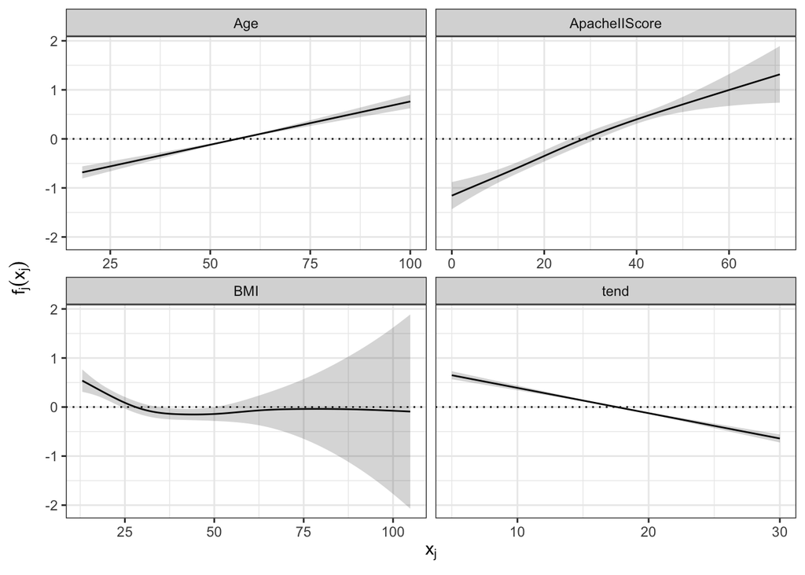

- non-smooth terms for categorical variables:
  - exponentiate the coefficients `exp(beta)` and interpret their **mulitplicative** effect on the hazard rate w.r.t the reference category
  - example 1: hazard rate for a person treated in 2009 is exp(-0.08622441) = 0.9173883 times as high as the hazard rate for similar person treated in 2007 (reference category)
  - example 2: hazard rate for a person with Metabolic cancer is exp(-0.92767602) = 0.3954717 times as high as the hazard rate for similar person with Gastrointestinal cancer (reference category)
  - For more, interpret this table:

```
##                                   beta        HR
## Year2008                    0.02718222 1.0275550
## Year2009                   -0.08622441 0.9173883
## Year2011                   -0.02328905 0.9769801
## AdmCatIDSurgical Elective  -0.47449956 0.6221964
## AdmCatIDSurgical Emergency -0.25667793 0.7736173
## DiagID2Cardio-Vascular      0.12438947 1.1324568
## DiagID2Other                0.10391129 1.1095020
## DiagID2Metabolic           -0.92767602 0.3954717
## DiagID2Neurologic           0.01267184 1.0127525
## DiagID2Orthopedic/Trauma   -0.26815998 0.7647854
## DiagID2Renal               -0.02733998 0.9730304
## DiagID2Respiratory         -0.13289109 0.8755604
## DiagID2Sepsis               0.05627062 1.0578839
```

# Frailty models

# Aalen model

# Cox-Aalen model

# Competing Risk models

```
## [1] "Jann"
```